# Gaussian Transformation

The Box-Cox transformation is an adaption of the exponential transformation, scanning through various exponents, and it already represents the untransformed variable, as well as the log transformed, reciprocal, square and cube root transformed, as the lambda varies across the range of -5 to 5. So by doing Box-Cox transformation, in a way, we are evaluating all the other transformations and choosing the best one. Box-Cox can only be applied to positive variables.

Yeo-Johnson is a modification of the Box-Cox transformation so that it can be applied as well to non-positive variables.

```python
import pandas as pd
import numpy as np
import os
import matplotlib.pyplot as plt
import scipy.stats as stats
```

```python
data = pd.read_csv('/home/sahil/Dhanya_notebooks/processed_files/data/houseprice.csv')
```

## Plot to assess normality

To visualise the distribution of the variables, we plot a histogram and a Q-Q plot. In the Q-Q plots, if the variable is normally distributed, the values of the variable should fall in a 45 degree line when plotted against the theoretical quantiles.

```python
# histogram and Q-Q plots

def diagnostic_plots(df, variable):

    # function to plot a histogram and a Q-Q plot side by side

    plt.figure(figsize=(15,6))
    plt.subplot(1, 2, 1)
    df[variable].hist(bins=30)

    plt.subplot(1, 2, 2)
    stats.probplot(df[variable], dist='norm', plot=plt)

    plt.show()
```

## Original distribution

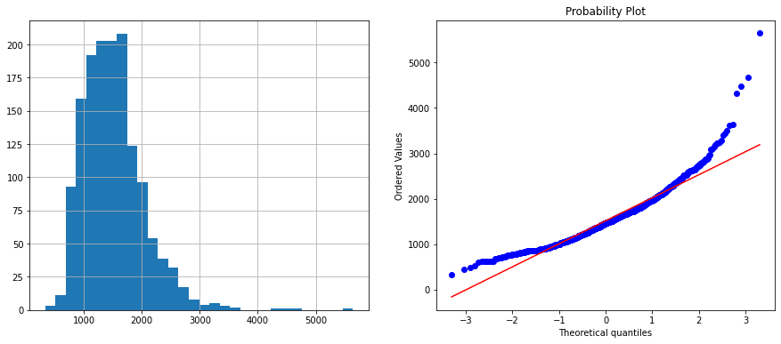

```python
diagnostic_plots(data, 'GrLivArea')
```

We can see in the plots that the variable is not normally distributed. We can see in the histogram that it is skewed to the right.

```
Optimal lambda:  0.006304841218621503
```

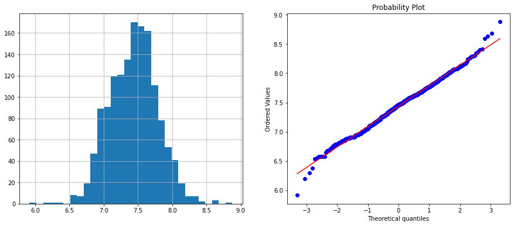

```python
# Box-Cox transformation

data['GrLivArea_boxcox'], param = stats.boxcox(data['GrLivArea'])

print('Optimal lambda: ', param)

diagnostic_plots(data, 'GrLivArea_boxcox')
```

## Yeo-Johnson

Yeo-Johnson is the same as Box-Cox for the positive values of the variable, but it has different equations for the negative values of the variable.

Again, the function searches over a bunch of lambda and selects the one that returns the best fit to a normal distribution.

```python
# to avoid a NumPy error

data['GrLivArea'] = data['GrLivArea'].astype('float')
```

```
Optimal lambda:  0.005539641278705955
```

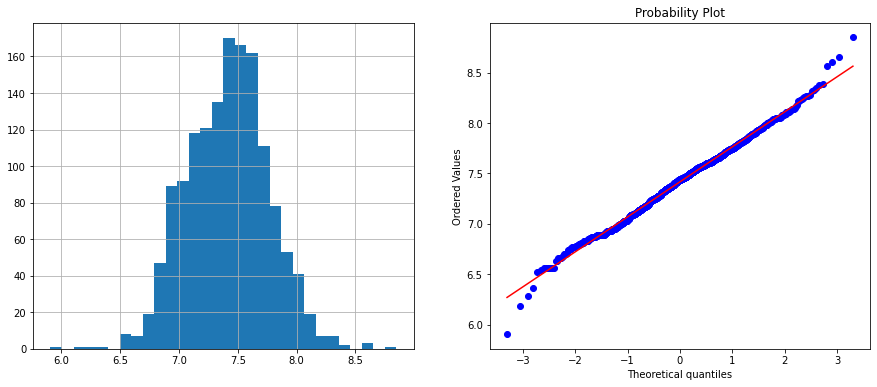

```python
data['GrLivArea_yeojohnson'], param = stats.yeojohnson(data['GrLivArea'])

print('Optimal lambda: ', param)

diagnostic_plots(data, 'GrLivArea_yeojohnson')
```